# Analysis of Spot Speed Data

Author

ECIV 542

Published

September 23, 2026

# Descriptive Statistics

- Central Tendency
  - **Mean**: sum of observed values (speed) divided by number of obs
  - **Median**: value (speed) that divides the data into equal parts
  - **Mode**: value at which most number of observations occur
  - **Pace**: a 10 mph block of max observation
- Dispersion
  - standard deviation

# Problem:

Figure 11.1 represents a typical set of field data from a spot speed study taken at a location of interest on a major arterial.

# Frequency Distribution Table

|  | spdLmtLower | spdLmtUpper | spdMiddle | numVeh | freq | cumulFreq | nS | nS2 |
| --- | --- | --- | --- | --- | --- | --- | --- | --- |
| 1 | 30 | 32 | 31 | 0 | 0 | 0 | 0 | 0 |
| 2 | 32 | 34 | 33 | 5 | 1.36 | 1.36 | 165 | 5445 |
| 3 | 34 | 36 | 35 | 5 | 1.36 | 2.72 | 175 | 6125 |
| 4 | 36 | 38 | 37 | 7 | 1.9 | 4.62 | 259 | 9583 |
| 5 | 38 | 40 | 39 | 13 | 3.53 | 8.15 | 507 | 19773 |
| 6 | 40 | 42 | 41 | 21 | 5.71 | 13.86 | 861 | 35301 |
| 7 | 42 | 44 | 43 | 33 | 8.97 | 22.83 | 1419 | 61017 |
| 8 | 44 | 46 | 45 | 46 | 12.5 | 35.33 | 2070 | 93150 |
| 9 | 46 | 48 | 47 | 65 | 17.66 | 52.99 | 3055 | 143585 |
| 10 | 48 | 50 | 49 | 40 | 10.87 | 63.86 | 1960 | 96040 |

[output cut: 10 more lines]

# Summary Statistics: Central Tendency

## Mean

- Sum number of observation in groups, $\sum{n_iS_i}$
- The total number of vehicle, $N$ *
- mean, $\bar{x} = \frac{\sum{n_iS_i}}{N}$
  - $N = 368$
  - $\sum{n_iS_i} = 1.7736\times 10^{4}$
  - $\bar{x} = \frac{1.7736\times 10^{4}}{368} = 48.2$ mph

## Meadian

- speed that divides the distribution into equal parts
  - there are as many observations of speeds higher than the median as there are lower than the median
- $N/2=368/2=184$ th observation divides the data into equal parts
- or, the speed at which $50%$ cumulative frequency is found
- From the table, $P_{50} = 47$ mph

## Mode

- Speed at which max observation occurs
- From Table: max observation is $65$ at speed $47$ mph
- Mode: $47$ mph

## Low Speed and High Speed

- Speed at which 15% drivers are driving
- From Table: 15% occurs between speed $41$ and $43$ mph; mean $42$ mph
- From the table, $P_{15} = 42$ mph
- Speed at which 85% drivers are driving
- From Table: 85% occurs between speed $53$ and $55$ mph; mean $54$ mph
- From the table, $P_{85} = 54$ mph

## Graphical Approach: Median, Mode, Pace

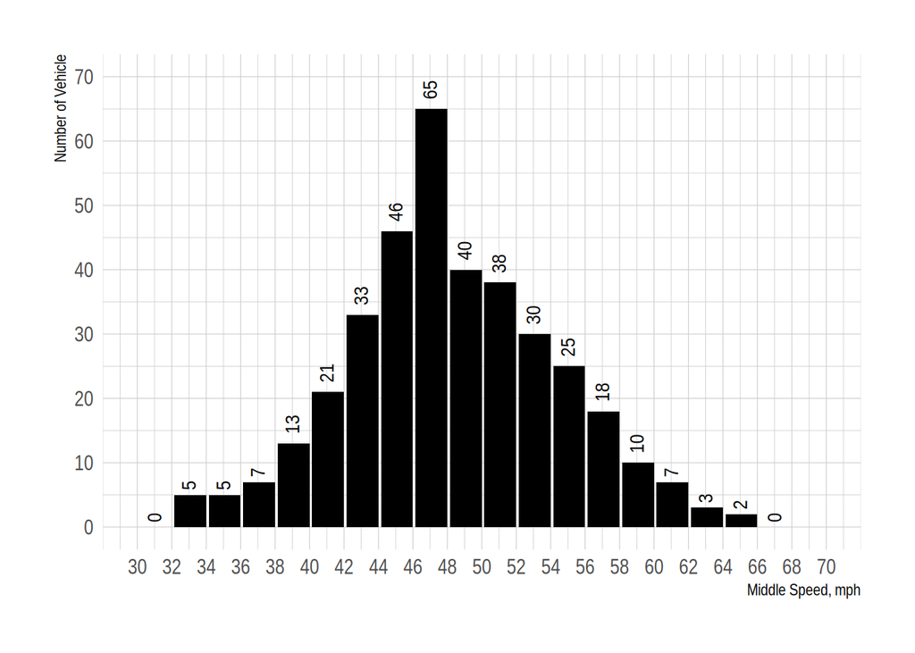

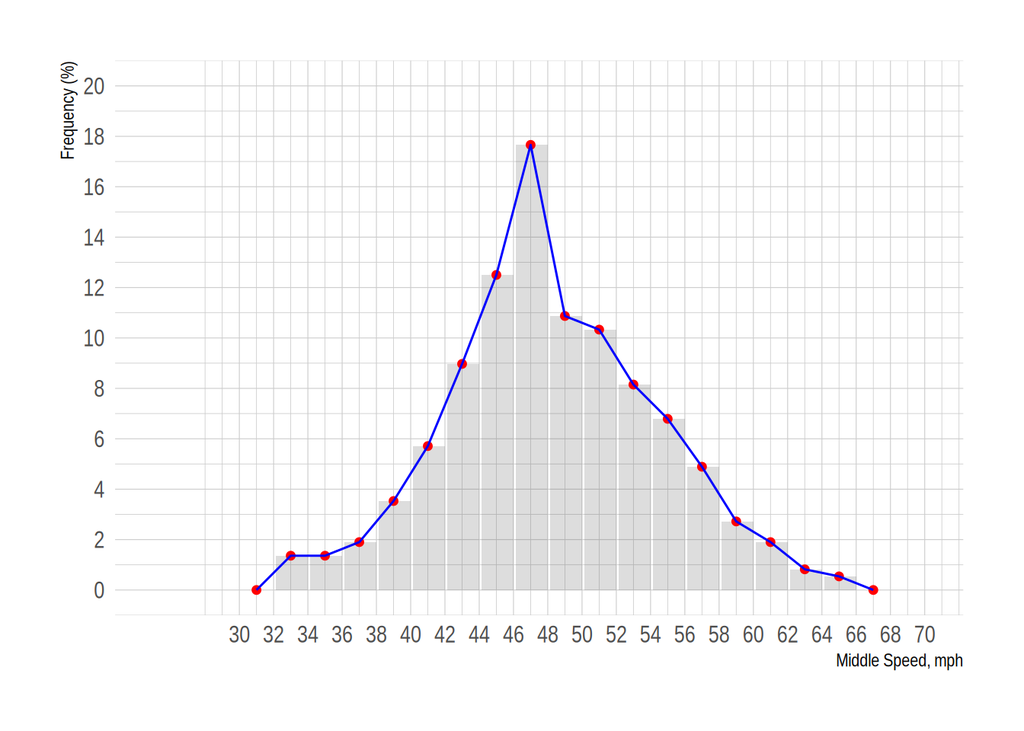

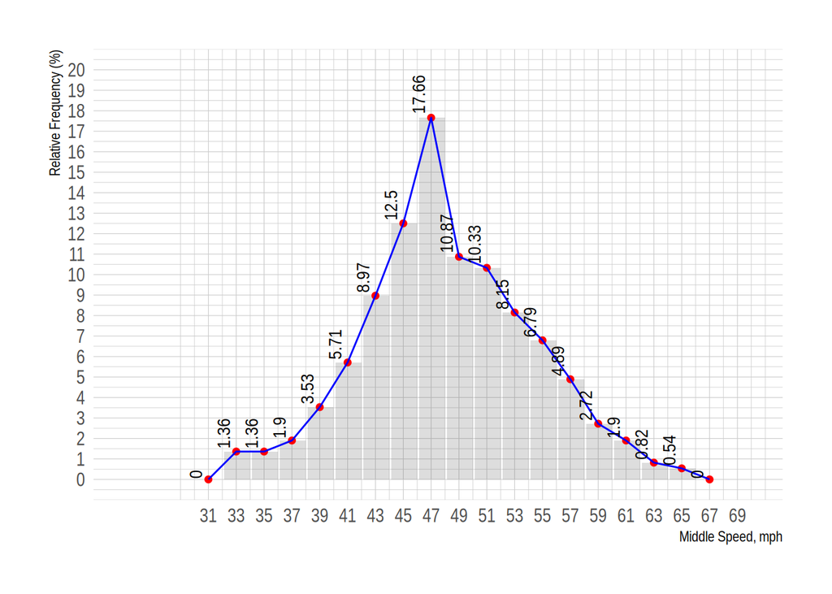

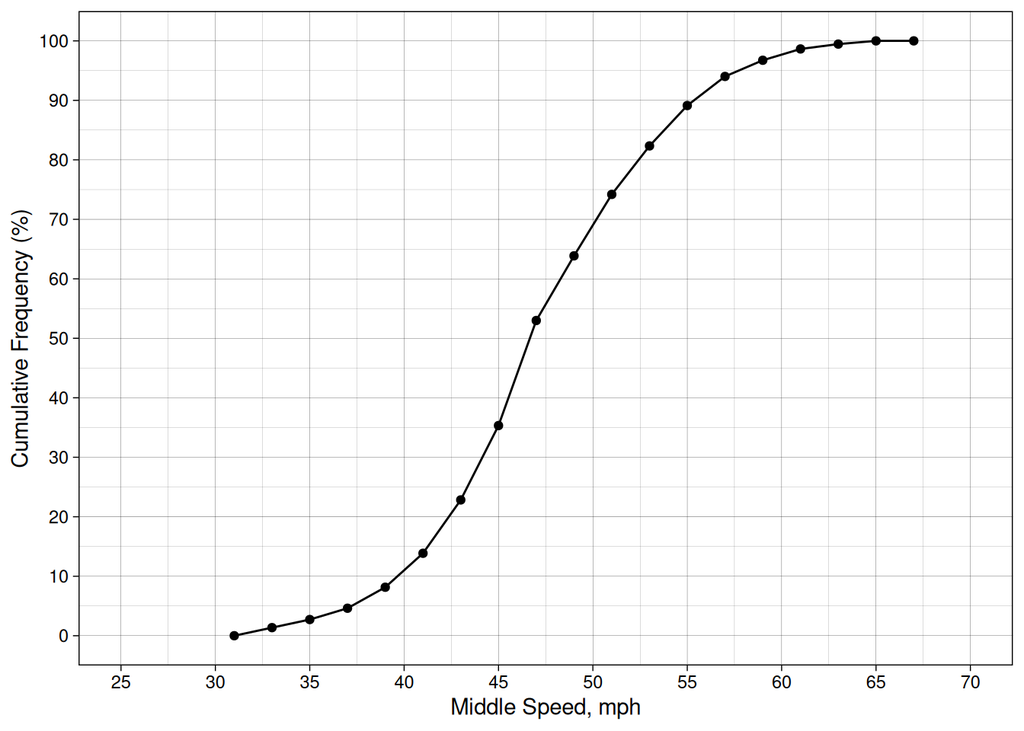

# Summary Statistics: Dispersion